# enerscape

# Energy Landscapes With Enerscape

Energy landscapes are spatially explicit projections of the energy cost of travel (kcal or J) for an animal. In enerscape, energy landscapes depend on the body mass of the animal and the incline between locations, following the ARC model from Pontzer (2016): https://doi.org/10.1098/rsbl.2015.0935. For a general overview of energy landscapes, refer to Berti et al. (2021): https://doi.org/10.1111/2041-210X.13734.

```r
library(terra)
library(enerscape)
```

Enerscape comes with the default dataset *sirente*; this is a matrix with values the digital elevation model (DEM) for Monte Sirente in Central Italy:

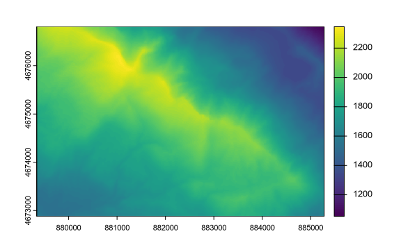

```r
data("sirente")
dem <- rast(
  sirente,
  crs = "+proj=utm +zone=32 +datum=WGS84 +units=m +no_defs",
  extent = ext(879340, 885280, 4672880, 4676810)
)
plot(dem)
```

I provided the correct coordinate reference system (CRS) and the extent of the DEM; in most cases, this will already be present in downloaded raster layers.

Enerscape assumes that the coordinate system is in meters:

```r
crs(dem, proj = TRUE)
```

```
#> [1] "+proj=utm +zone=32 +datum=WGS84 +units=m +no_defs"
```

You **have** to check this by yourself to make sure *+units=m* or enerscape results will not be meaningful. Enerscape checks if this is the case and returns a warning if *+units* does not match *m*, but it will still return its output.

The energy landscapes can be obtained with the *enerscape()* function. There are two mandatory inputs: *dem*, which is the SpatRaster of the DEM, and *mass*, which is the body mass of the animal (kg).

```r
en <- enerscape(dem, 10, neigh = 4, unit = "kcal")
```

```
#> DEM is assumed to have planar CRS in meters.
```

Before visualizing it, it is worth nothing that, from my experience, energy landscape values are usually right-skewed, i.e. with most cells having low values and few cells having high values. In such cases, it is useful to log-transform energy landscape for visualization:

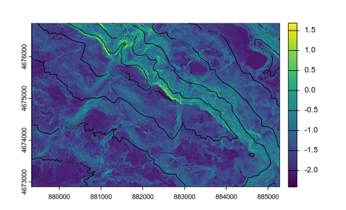

```r
en_log <- log(en)
plot(en_log)
terra::contour(dem, add = TRUE, nlevels = 5)
```

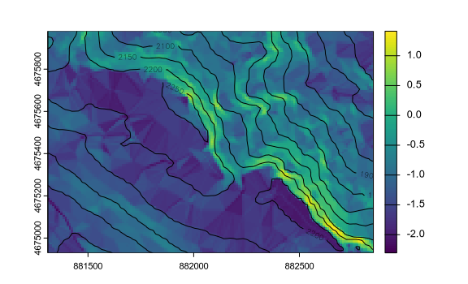

```r
en_log <- crop(en_log, ext(881306, 882853, 4674928, 4675984))
plot(en_log)
terra::contour(dem, add = TRUE, nlevels = 20)
```